# Generating gene lists: GC biases in mouse

```
## [[1]]
## <environment: namespace:GOcategoryStats>
```

#### Creating lists of mouse genes biased by GC content.

To generate the lists, a file containing the GC content of all the genes in the mouse genome is required.

We’re only doing high and low GC content, I’ve previously looked at other GC intervals and didn’t find any biases.

## Pre-processing of data on cluster

The script create_gene_info_file_from_gtf.pl takes a gtf file and parses it to create a gene info file that contains all the genes that are annotated in the gtf file. This should be all the genes in that version of the genome.

/bi/group/bioinf/Laura_B/bias_analysis/in_silico/in_silico_datasets/GC

Downloaded the raw version of the file from github `wget https://raw.githubusercontent.com/s-andrews/GOliath/master/processing/` `gene_info_processing/create_gene_info_file_from_gtf.pl`

Run this script to create the gene info file `perl create_gene_info_file_from_gtf.pl --gtf Mus_musculus.GRCm38.94.gtf.gz --genome GRCm38`

We’ll import the gene info file so that we can plot the GC distribution for all genes in the Mus_musculus.GRCm38.94.gtf.gz genome. There are import_GTF and parse_GTF_info functions within the GOcategoryStats package but to get genome information i.e. GC content, the parsing and lookups need to be done with access to genome information, so on the cluster. The import_GTF and parse_GTF_info functions just work with the gtf file itself.

Plot out the GC distribution for all the genes in Mus_musculus.GRCm38.94

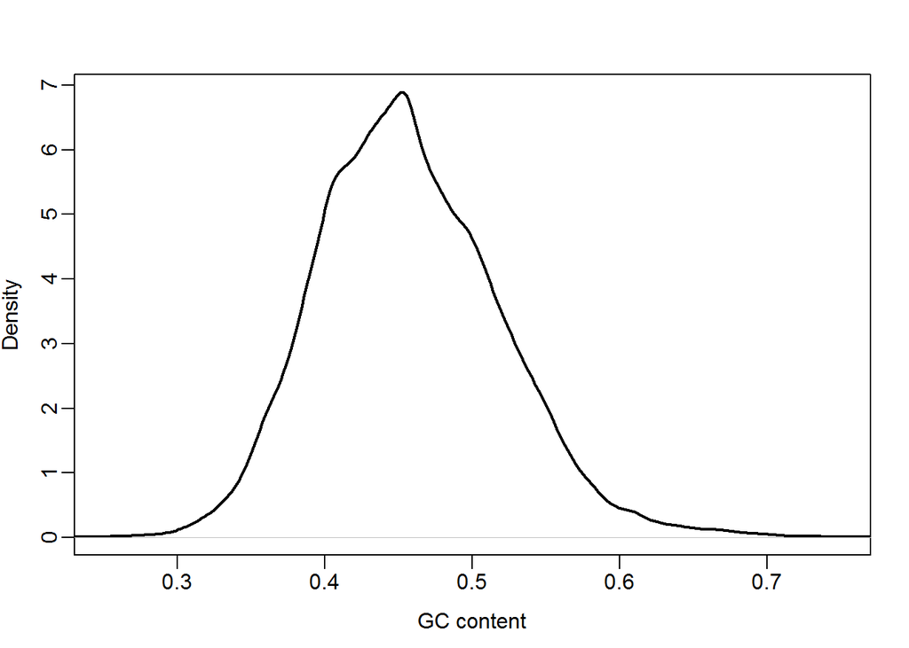

####Select GC thresholds.

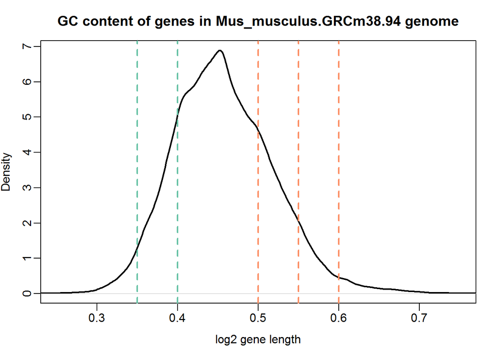

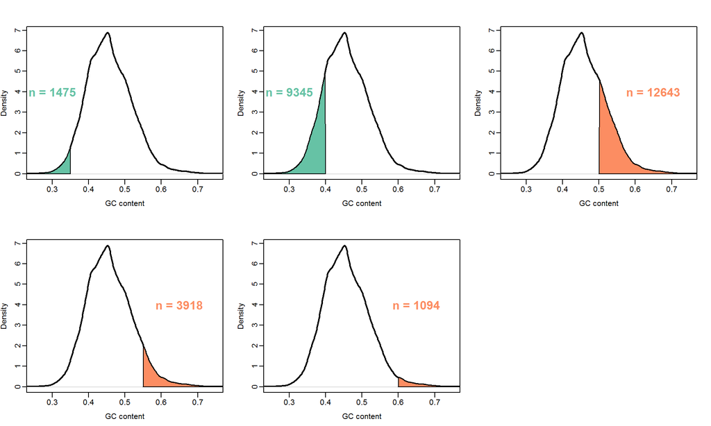

### Further pre-processing: Generating the biased gene lists

### Generating the biased gene lists within R

Check they all look right

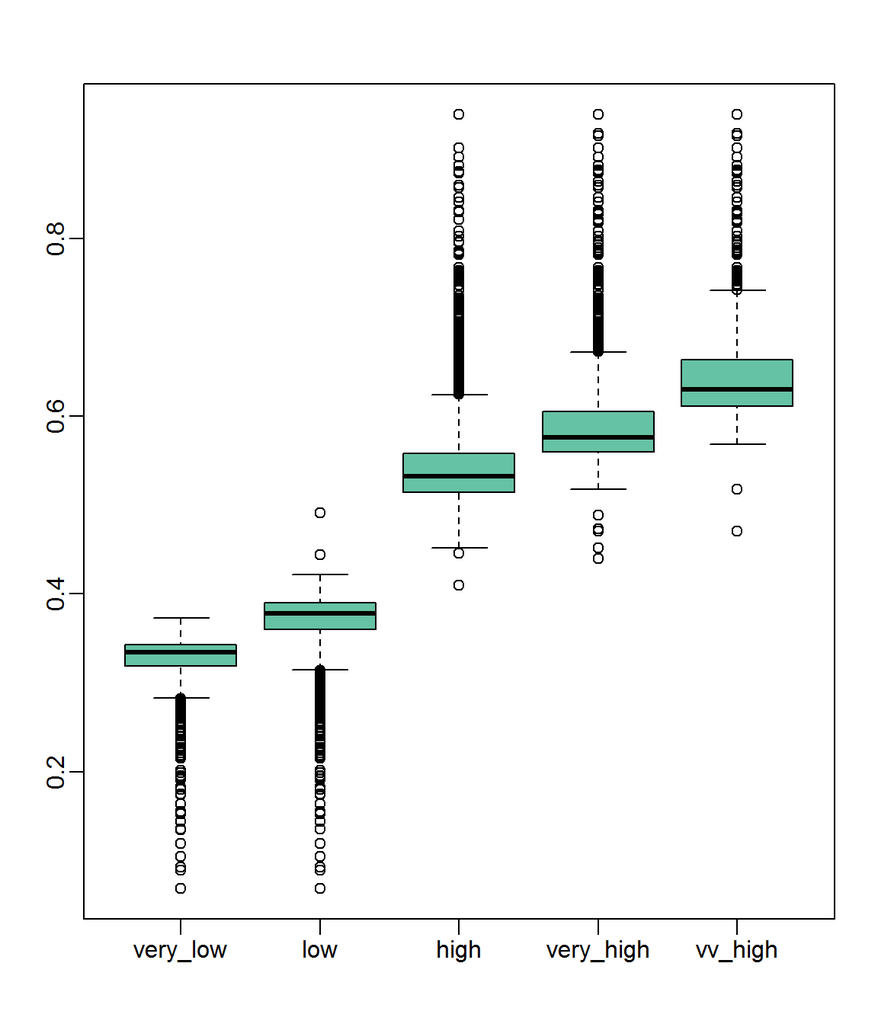

### GO overrepresentation analysis

Run the gene lists through a GO overrepresentation analysis.

Any categories with 0 significant results can be removed.

```
##  very_low       low      high very_high   vv_high
##     FALSE     FALSE     FALSE     FALSE     FALSE
```

We don’t want to run the GO analysis each time the document is knitted as it takes too long. The code was run once and the data saved as an .rda object that can be quickly loaded in to the R session.

See how many significant categories were returned for each gene list.

```
## [1] "GC_results"
```

The number of gene sets that returned significant results from the GO overrepresentation analysis

```
##  very_low       low      high very_high   vv_high
##       100        90        13        15        20
```

The bean plots show the number of categories returned from each gene list. The null results have been removed.

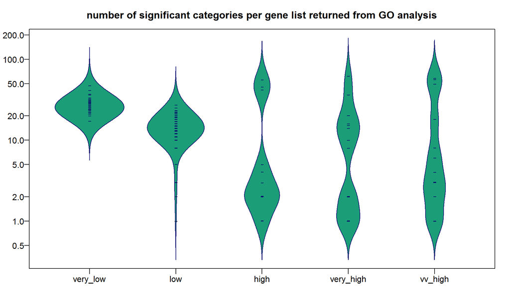

Plot out the p and q values

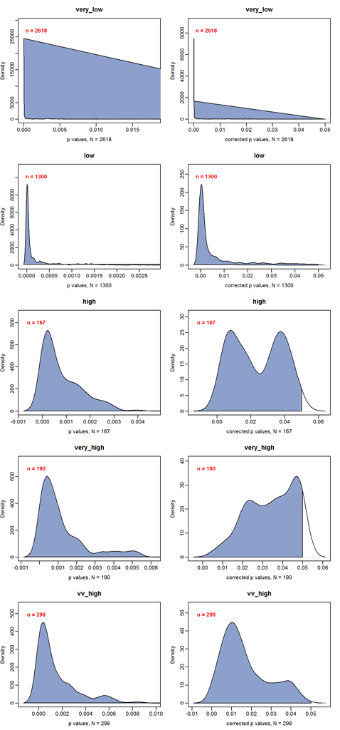

beanplot didn’t work Error in bw.SJ(x, method = “dpi”) : sample is too sparse to find TD

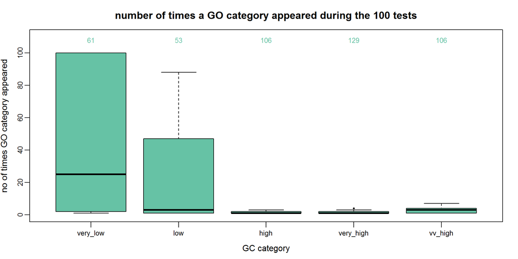

Replot just showing the data for categories that appeared >= 10 times

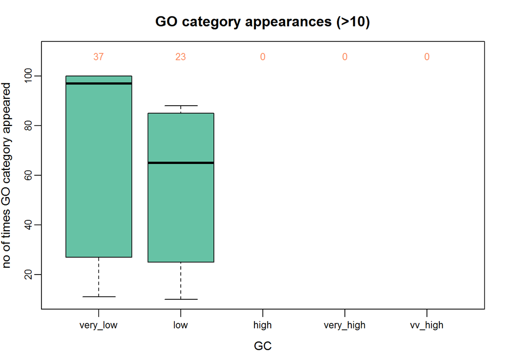

Create a dataset that contains these suspect set of categories

```
##  very_low       low      high very_high   vv_high
##        37        23         0         0         0
```

We don’t need empty files so remove GC categories with no results.

```
## very_low      low
##       37       23
```

Deduplicate

```
## [1] 23
```

```
## [1] 23
```

There are 23 overlapping categories between very low and low so I’ll remove them from the very low category.

```
## very_low      low
##       14       23
```

`for i in {1..100}; do ../filter_gene_info.pl --max_GC 0.6 ../Mus_musculus.GRCm38.94_gene_info.txt` `--number_of_genes 200 --output_file highGC_0.6_${i}; done`

Extract the gene names and remove header `for i in highGC*; do cut -f2 $i | tail -n 200 > ${i}_just_genes.txt; done`